# Implementando ICs - Last.fm

Elton Dantas de Oliveira Mesquita

# Os dados

```r
set.seed(12345)

populacao = read_csv(here::here("data/experimento-lastfm.csv"),
                  col_types = cols(.default = col_double(),
                                   user = col_character())) %>%
    filter(!is.na(old)) %>%
    mutate(prop_news = news/(news + old))

lastfm = populacao %>%
  sample_n(300) %>%
  select(news, old, mediana_pop, prop_news)

glimpse(lastfm)
```

```
## Observations: 300
## Variables: 4
## $ news        <dbl> 71, 13, 14, 18, 29, 14, 13, 157, 23, 11, 22, 35, 7...
## $ old         <dbl> 157, 61, 162, 180, 104, 80, 97, 752, 61, 116, 68, ...
## $ mediana_pop <dbl> 5.783615, 5.745970, 6.073937, 5.595928, 5.176068, ...
## $ prop_news   <dbl> 0.31140351, 0.17567568, 0.07954545, 0.09090909, 0....
```

# Proporção de artistas novos e popularidade

Utilizaremos ICs para estimar duas métricas sobre os usuários do LastFM em geral durante um período de 6 meses. Em ambos os casos faremos isso a partir de uma amostra de 300 usuários. As duas métricas são:

## 1. Qual a proporção de novos artistas escutados pelos usuários?

### Aplicando o bootstraping

```r
theta_f = function(df) {
  df %>%
    summarise(mean_prop_news = mean(prop_news)) %>%
    pull(mean_prop_news)
}

theta = theta_f(populacao)
theta
```

```
## [1] 0.2467958
```

```r
theta_c = theta_f(lastfm)
theta_c
```

```
## [1] 0.2376112
```

```r
repeticoes = 5000 # pelo menos 2000, mas mais não faz mal.

um_bootstrap <- function(x){
    reamostra = x %>%
        sample_n(size = NROW(x),
                 replace = TRUE)
    proporcoes = reamostra %>%
        mutate(proporcao = news / (news + old)) %>%
        pull(proporcao)

    return(mean(proporcoes))
}

um_bootstrap(lastfm)
```

```
## [1] 0.2388827
```

```r
set.seed(1212)

# A REAMOSTRAGEM
reamostragens = tibble(i = 1:repeticoes) %>%
  mutate(theta_c_s = map_dbl(i, ~ um_bootstrap(lastfm)))

reamostragens
```

| i | theta_c_s |
| --- | --- |
| 1 | 0.2362692 |
| 2 | 0.2419738 |
| 3 | 0.2403668 |
| 4 | 0.2350869 |
| 5 | 0.2398918 |
| 6 | 0.2374482 |
| 7 | 0.2362048 |
| 8 | 0.2310611 |
| 9 | 0.2531951 |
| 10 | 0.2365387 |

[output cut: 4990 more lines]

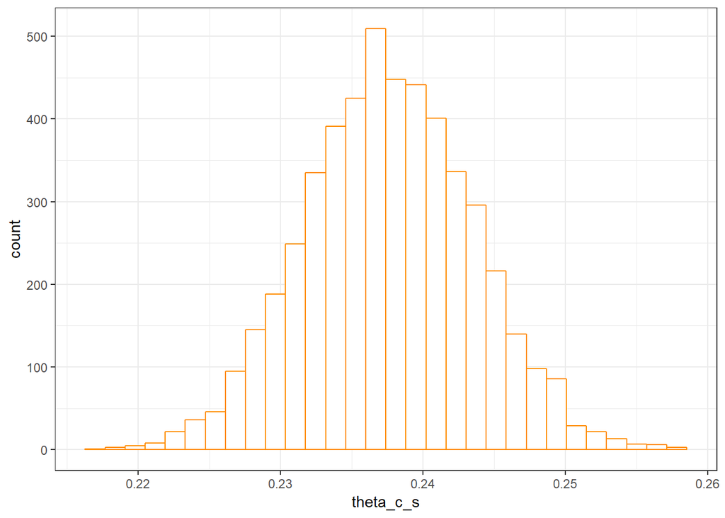

```r
reamostragens %>%
  ggplot(aes(x = theta_c_s)) +
  geom_histogram(colour = "darkorange",
                 fill = "white")
```

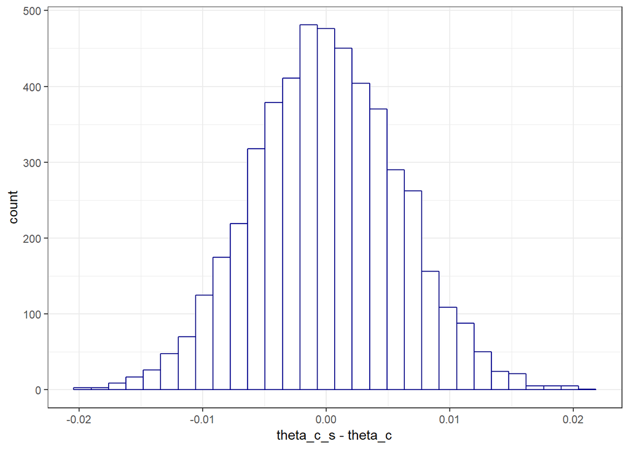

```r
reamostragens %>%
  ggplot(aes(x = theta_c_s - theta_c)) +
  geom_histogram(colour = "darkblue",
                 fill = "white")
```

### Calculando o IC

Agora usamos a distribuição de $\delta* = \hat{\theta}* - \hat{\theta}$ no lugar da de $\delta$.

```r
intervalo = reamostragens %>%
  mutate(erro = theta_c_s - theta_c) %>%
  summarise(erro_i = quantile(erro, .05),
            erro_s = quantile(erro, .95))

intervalo
```

| erro_i | erro_s |
| --- | --- |
| -0.009652624 | 0.009827124 |

Agora fazemos o mesmo que antes para estimar onde $\theta$ está usando $\hat{\theta}$.

```r
intervalo = intervalo %>%
  mutate(valor_i = theta_c + erro_i,
         valor_s = theta_c + erro_s)

intervalo
```

| erro_i | erro_s | valor_i | valor_s |
| --- | --- | --- | --- |
| -0.009652624 | 0.009827124 | 0.2279585 | 0.2474383 |

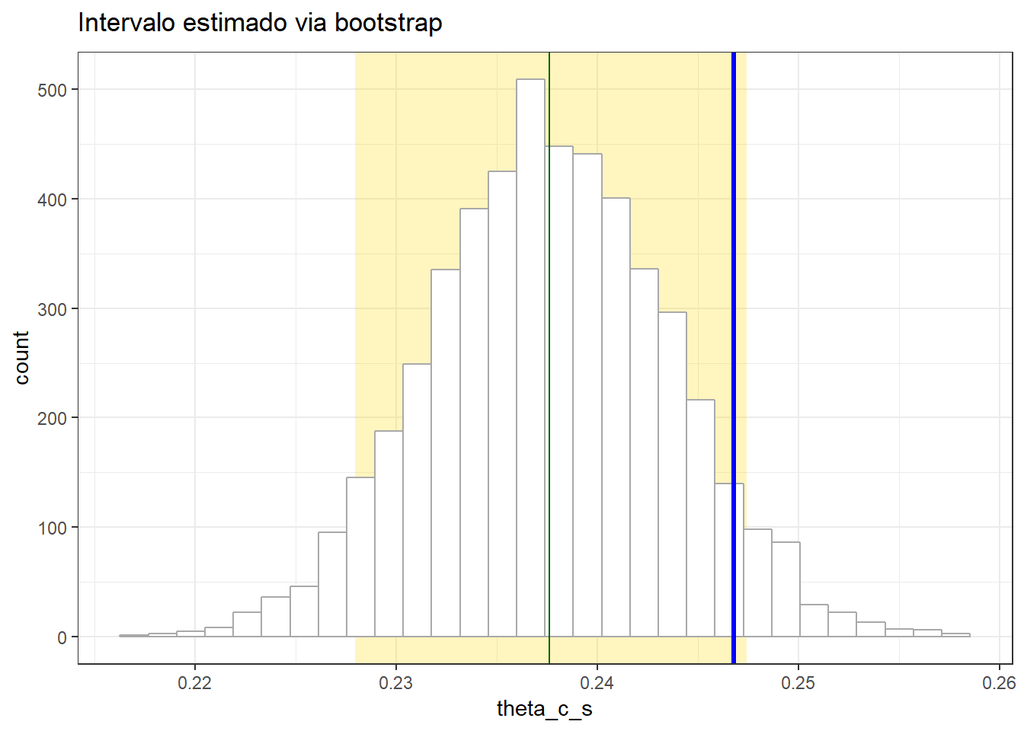

```r
ggplot() +
  geom_rect(
    data = intervalo,
    aes(xmin = valor_i, xmax = valor_s),
    ymin = -Inf,
    ymax = Inf,
    fill = "gold",
    alpha = .25
  ) +
  geom_histogram(
    data = reamostragens,
    aes(theta_c_s),
    fill = "white",
    colour = "darkgrey"
  ) +
  geom_vline(xintercept = theta,
             color = "blue",
             size = 1.2) +
  geom_vline(xintercept = theta_c, color = "dark green") +
  labs(title = expression("Intervalo estimado via bootstrap"))
```

## 2. Para os usuários que gostam de música muito pop (mediana_pop > 5), qual a correlação entre a popularidade mediana dos artistas escutados e a proporção dos artistas escutados que eram novos.

### Aplicando o bootstraping

```r
theta_f = function(df) {
  df %>%
    filter(mediana_pop > 5) %>%
    summarise(correlacao = cor(mediana_pop,
                               prop_news)) %>%
    pull(correlacao)
}

set.seed(1212)

theta = theta_f(populacao)
theta
```

```
## [1] -0.02790772
```

```r
theta_c = theta_f(lastfm)
theta_c
```

```
## [1] -0.01052332
```

```r
repeticoes = 5000 # pelo menos 2000, mas mais não faz mal.

um_bootstrap <- function(x){
    reamostra = x %>%
        sample_n(size = NROW(x),
                 replace = TRUE)
    correlacoes = reamostra %>%
        mutate(correlacao = cor(mediana_pop,
                                prop_news)) %>%
        pull(correlacao)

    return(mean(correlacoes))
}

um_bootstrap(lastfm)
```

```
## [1] 0.01809829
```

```r
set.seed(1212)

# A REAMOSTRAGEM
reamostragens = tibble(i = 1:repeticoes) %>%
  mutate(theta_c_s = map_dbl(i, ~ um_bootstrap(lastfm)))

reamostragens
```

| i | theta_c_s |
| --- | --- |
| 1 | 1.809829e-02 |
| 2 | 5.481953e-02 |
| 3 | 9.935170e-02 |
| 4 | 9.036290e-03 |
| 5 | -4.410723e-02 |
| 6 | 1.634065e-02 |
| 7 | -7.820309e-02 |
| 8 | 6.056467e-02 |
| 9 | 7.898654e-02 |
| 10 | 1.743074e-02 |

[output cut: 4990 more lines]

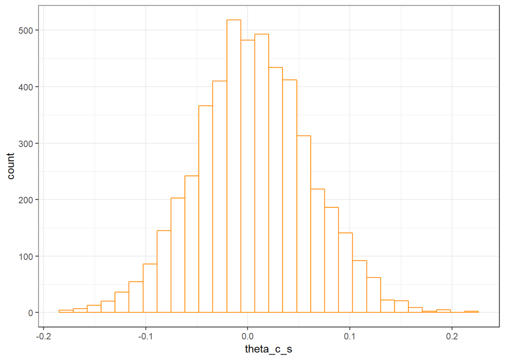

```r
reamostragens %>%
  ggplot(aes(x = theta_c_s)) +
  geom_histogram(colour = "darkorange",
                 fill = "white")
```

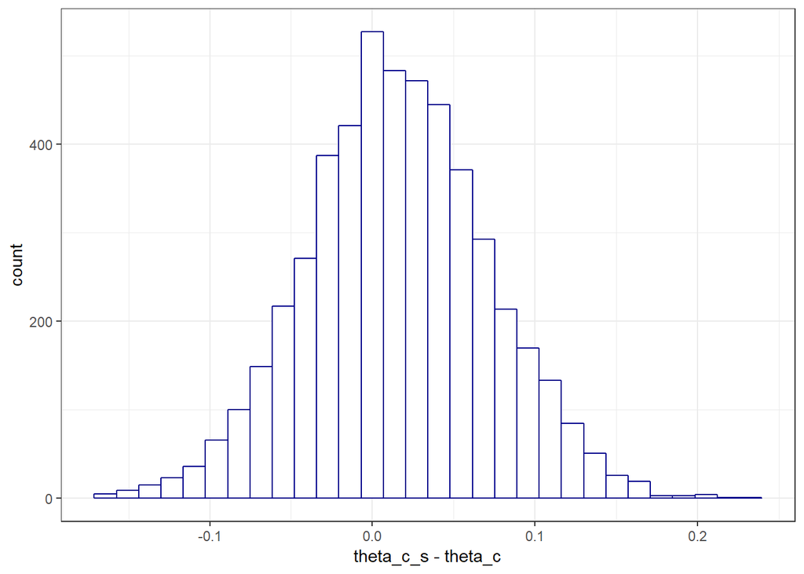

```r
reamostragens %>%
  ggplot(aes(x = theta_c_s - theta_c)) +
  geom_histogram(colour = "darkblue",
                 fill = "white")
```

### Calculando o IC

```r
intervalo = reamostragens %>%
  mutate(erro = theta_c_s - theta_c) %>%
  summarise(erro_i = quantile(erro, .05),
            erro_s = quantile(erro, .95))

intervalo = intervalo %>%
  mutate(valor_i = theta_c + erro_i,
         valor_s = theta_c + erro_s)

intervalo
```

| erro_i | erro_s | valor_i | valor_s |
| --- | --- | --- | --- |
| -0.07592583 | 0.109524 | -0.08644915 | 0.0990007 |

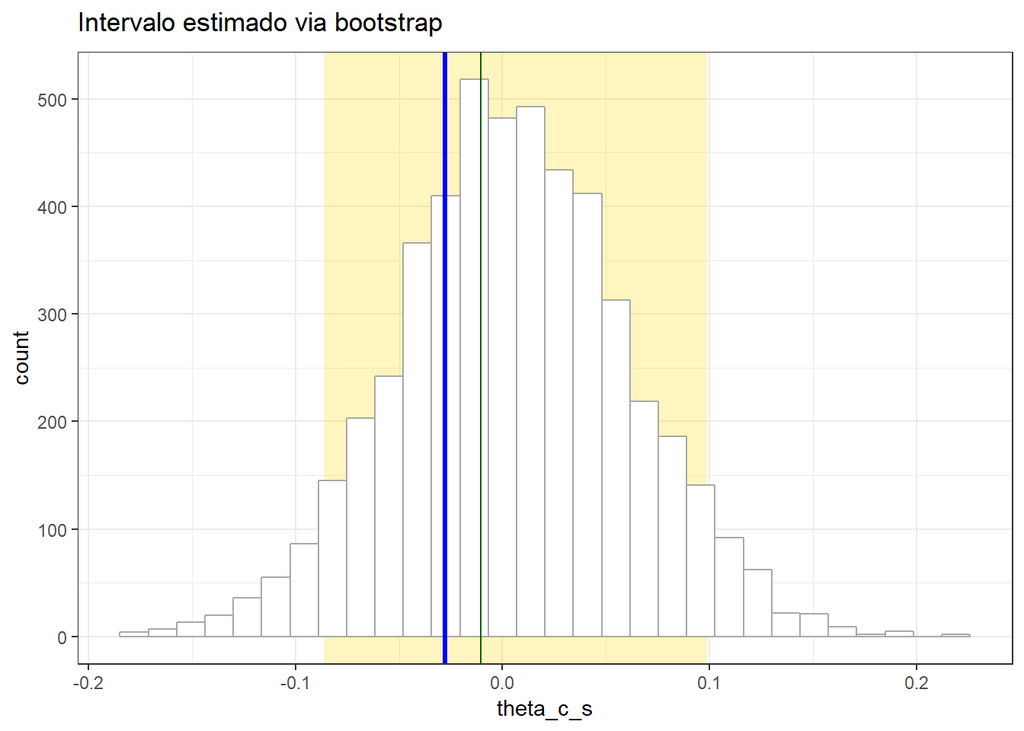

```r
ggplot() +
  geom_rect(
    data = intervalo,
    aes(xmin = valor_i, xmax = valor_s),
    ymin = -Inf,
    ymax = Inf,
    fill = "gold",
    alpha = .25
  ) +
  geom_histogram(
    data = reamostragens,
    aes(theta_c_s),
    fill = "white",
    colour = "darkgrey"
  ) +
  geom_vline(xintercept = theta,
             color = "blue",
             size = 1.2) +
  geom_vline(xintercept = theta_c, color = "dark green") +
  labs(title = expression("Intervalo estimado via bootstrap"))
```

# Utilizando a biblioteca Boot

## 1. Qual a proporção de novos artistas escutados pelos usuários?

```r
theta_prop = function(d,i){
    d %>%
        slice(i) %>%
        summarise(mean_prop_news = mean(prop_news)) %>%
        pull(mean_prop_news)
}
```

```r
intervalo1 = lastfm %>%
    boot(statistic = theta_prop,
         R = 4000) %>%
    tidy(conf.level = 0.95,
         conf.int = TRUE)

intervalo1
```

| statistic | bias | std.error | conf.low | conf.high |
| --- | --- | --- | --- | --- |
| 0.2376112 | 7.292552e-05 | 0.005991598 | 0.2262555 | 0.2496067 |

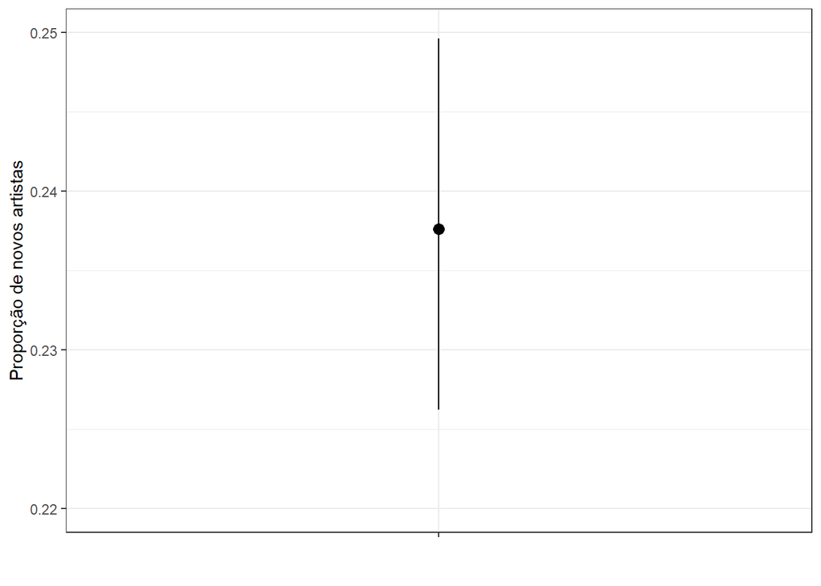

```r
intervalo1 %>%
    ggplot(aes(
        x = "",
        y = statistic,
        ymin = conf.low,
        ymax = conf.high
    )) +
    geom_pointrange() +
    geom_point(size = 3) +
    ylim(.22, .25) +
    labs(x = "", y = "Proporção de novos artistas")
```